### [**HOME**](http://mpark673.github.io/) | [**ABOUT ME**](http://mpark673.github.io/about_me/) | [**RESEARCH**](http://mpark673.github.io/research/) | [**PROJECTS**](http://mpark673.github.io/projects)

# Phage Library

### Intro and Background

This project serves as a starting point for genome analysis on newly sequenced phage genomes. Identifying evolutionary relationships between phages and their hosts can help discover key genes or sequences that lead to evolutionary success. When analyzing new phage genomes, comparing against known phages that target the same or similar hosts can assist in identifying known virulence factors, integration segments, and host range. *Salmonella* was selected as the target bacterial host, as the various species of *Salmonella* cause 98 million infections per year [(CDC, 2022).](https://www.cdc.gov/salmonella/index.html) They are also the most common food-borne pathogen to humans, and with antibiotic resistant strains becoming increasingly difficult to treat, using phage therapy has become a popular alternative.

### Data collection

Phage genomes were pulled from NCBI. All listed whole genome reads of phages with hosts in the *Salmonella* family of bacteria were selected. A total of 14 whole genome sequences were found and saved as “fna.gz” files for use.  
*Table 1: List of all phage genomes and accession numbers*

| Genome Accession and Sequence Name |
| --- |
| NC_022768.1 Salmonella phage Maynard, complete genome |
| NC_022772.1 Salmonella phage Marshall, complete genome |
| NC_028754.1 Salmonella phage Shivani, complete genome |
| NC_027297.1 Salmonella phage Stitch, complete genome |
| NC_047786.1 Salmonella phage vB_SenS_Sasha, complete genome |
| NC_041923.1 Salmonella phage Mushroom, complete genome |
| NC_042044.1 Salmonella phage Melville, complete genome |
| NC_049428.1 Salmonella phage Mutine, complete genome |
| NC_054639.1 Salmonella phage Skate, complete genome |
| NC_048727.1 Salmonella phage Siskin, complete genome |
| NC_048062.1 Salmonella phage Sw2, complete genome |
| NC_048110.1 Salmonella phage Seafire, complete genome |
| NC_048760.1 Salmonella phage Sepoy, complete genome |
| NC_069152.1 Salmonella phage Shemara, complete genome |

### Synteny Alignment using a Database

Genomes were oriented and sequence names were shortened to make the data easier to read. Each genome was then saved to a database. Using a database allows for long term storage of sequences along with a quick easy way to add and align more, new sequences. The database also allows for easy multiple genome alignment without needing a high power supercomputer. Synteny alignment tends to be less accurate, but for the purposes of finding which phages that are generally closely related it works well. Synteny alignment is then visualized to identify closely related sequences.  
*Graph 1: Synteny visualization for all 14 phage genomes.*

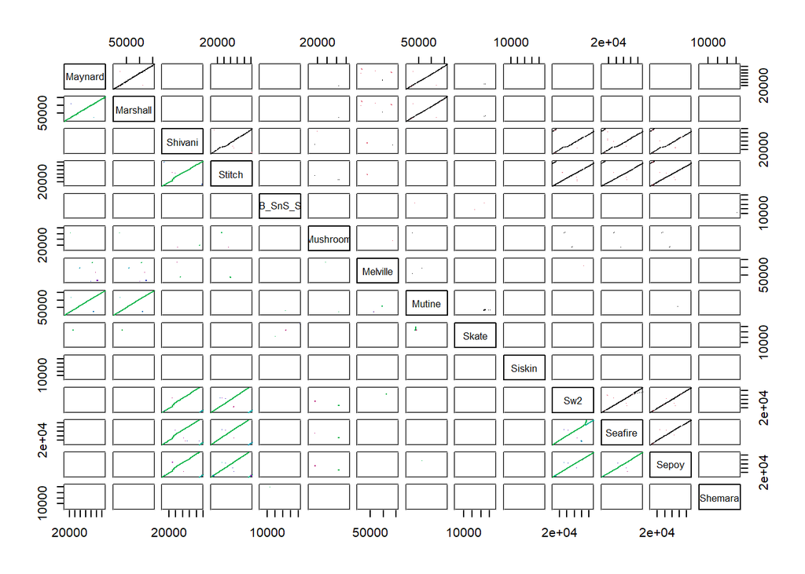

### Determining Significant Alignment

The synteny was put through another alignment algorithm that assorted the sequences into individual alignments with each other. Significant alignment was assigned as (alignment >= 5.0%), 100% being identical sequences and 0% sharing no genetic information. Each significant alignment was then saved to FASTA format for further analysis with NCBI BLAST programs and future comparison with newly sequenced phages.

#### Why whole genomes?

| Phage Alignment | Alignment Length (bp) |
| --- | --- |
| Maynard/Marshall | 157016 |
| Maynard/Mutine | 167468 |
| Marshall/Mutine | 167797 |
| Shivani/Stitch | 137332 |
| Shivani/Sw2 | 126297 |
| Shivani/Seafire | 123802 |
| Shivani/Sepoy | 127211 |
| Stitch/Sw2 | 116028 |
| Stitch/Seafire | 118703 |
| Stitch/Sepoy | 115699 |
| Sw2/Seafire | 115930 |
| Sw2/Sepoy | 116358 |
| Seafire/Sepoy | 118680 |

*Table 3: 1000 base pair (bp) segments of each alignment: Sequences starting with the same number are aligned with each other.*

[interactive chart not shown]

### Individual Phage Genome Analysis

Once a novel phage genome has been identified, further analysis of the individual genome will be performed to find open reading frames (ORFs) that help identify genes. For demonstration purposes, the Maynard phage genome will be used as a proxy for the novel phage genome. ORF length was set at 300 bp. This seems to be a tipping point in the algorithm as the shortest ORF returned was 960 bp long, over triple the minimum allowed by the function. It also only returned 30 ORFs, while lower length ORF algorithms (eg. 100 base pairs) can return over 1000 individual ORFs. Phage genome length seems to be associated with gene content. Short, 15 kbp phage genomes tend to have around 6-11 genes for their entire genome, while longer, 1.2 mbp genomes can have up to 1200 genes [(Chaitanya, 2019)](https://doi.org/10.1007/978-981-15-0702-1_1). Given the 150 kbp length of the Maynard genome, 30 genes seems to close to the expected amount for a similarly sized genome.  
*Table 4: List of all open reading frames >= 300 base pairs in length*

| ORF length | ORF ID |
| --- | --- |
| 3174 | ORF_1_Maynard |
| 2244 | ORF_2_Maynard |
| 2211 | ORF_3_Maynard |
| 1131 | ORF_4_Maynard |
| 2400 | ORF_5_Maynard |
| 2283 | ORF_6_Maynard |
| 1044 | ORF_7_Maynard |
| 1929 | ORF_8_Maynard |
| 1683 | ORF_9_Maynard |
| 990 | ORF_10_Maynard |
| 2358 | ORF_11_Maynard |
| 1104 | ORF_12_Maynard |
| 1038 | ORF_13_Maynard |
| 960 | ORF_14_Maynard |
| 1425 | ORF_15_Maynard |
| 1833 | ORF_16_Maynard |
| 1191 | ORF_17_Maynard |
| 2097 | ORF_18_Maynard |
| 2367 | ORF_19_Maynard |
| 4896 | ORF_20_Maynard |
| 1323 | ORF_21_Maynard |
| 1599 | ORF_22_Maynard |
| 1221 | ORF_23_Maynard |
| 2040 | ORF_24_Maynard |
| 1602 | ORF_25_Maynard |
| 2334 | ORF_26_Maynard |
| 1068 | ORF_27_Maynard |
| 1086 | ORF_28_Maynard |
| 1194 | ORF_29_Maynard |
| 1428 | ORF_30_Maynard |

*Table 5: First 960 base pairs of each open reading frame found in the Maynard genome.*

[interactive chart not shown]

### References

CDC. (2021, November 23). 2019 antibiotic resistance threats report. Centers for Disease Control and Prevention. Retrieved November 14, 2022, from https://www.cdc.gov/drugresistance/biggest-threats.html

CDC. (2022, November 10). Salmonella homepage. Centers for Disease Control and Prevention. Retrieved November 15, 2022, from https://www.cdc.gov/salmonella/index.html

Chaitanya, K. V. (2019). Structure and Organization of Virus Genomes. Genome and Genomics, 1–30. https://doi.org/10.1007/978-981-15-0702-1_1

Mavrich, T. N., & Hatfull, G. F. (2017). Bacteriophage evolution differs by host, lifestyle and genome. Nature Microbiology, 2, 17112. https://doi.org/10.1038/nmicrobiol.2017.112